# Que 2014 seja um ano melhor para a Petrobrás

#### Wilson Freitas

25/01/2014

Categoria: [finance](https://wilsonfreitas.github.io/category/finance.html)

Tags: [finance](https://wilsonfreitas.github.io/tag/finance.html) [python](https://wilsonfreitas.github.io/tag/python.html) [visualization](https://wilsonfreitas.github.io/tag/visualization.html)

O objetivo aqui é tentar reproduzir os resultados [deste *post*](http://www.opequenoinvestidor.com.br/2014/01/que-2014-seja-finalmente-um-novo-ano-para-petrobras/) (do blog [o pequeno investidor](http://www.opequenoinvestidor.com.br/)) que avalia alguns indicadores da Petrobrás no cenário atual, começo de 2014, utilizando Python e alguns pacotes do *stack* científico.

Vamos começar importando os dados e para isso vamos utilizar o **pandas**. **pandas** possui uma classe denominada `DataFrame` que pode carregar dados em formatos híbridos em uma estrutura tabular. Isso é muito legal porque em muitos casos os dados não estão em formatos numéricos e frequentemente é necessário, mesmo em dados numéricos, que eles sejam categorizados e ao invés de utilizar códigos sem sentido podemos lançar mão de identificadores de texto. Mas felizmente os dados que vamos começar a análisar são numéricos e representam o a Demostração de Resultados da Petrobrás. Estes dados foram obtidos do site [Fundamentus](http://www.fundamentus.com.br/) que organiza as informações históricas de Balanço e Demostração de Resultados para diversas empresas, de graça!

```python
import numpy as np
import matplotlib.pyplot as plt
import pandas as pd
import sys
%pylab inline
print 'python', sys.version
print 'pandas', pd.__version__
```

```
python 2.7.6 (default, Nov 28 2013, 23:33:48)
[GCC 4.2.1 Compatible Apple LLVM 5.0 (clang-500.2.79)]
pandas 0.13.0
```

## Importando os dados

Vamos começar a análise observando os dados de resultados operacionais da Petrobrás: **Receita Líquida** e **Lucro Líquido**. Estas variáveis se encontram no Demonstrativo de Resultados da empresa, e estão no arquivo `PETR balanco - T Dem. Result.csv`. Vamos começar dando uma olhada nesse arquivo.

```python
!head -3 'PETR balanco - T Dem. Result.csv'
```

```
Data,Receita Bruta de Vendas e/ou Serviços,Deduções da Receita Bruta,Receita Líquida de Vendas e/ou Serviços,Custo de Bens e/ou Serviços Vendidos,Resultado Bruto,Despesas Com Vendas,Despesas Gerais e Administrativas,Perdas pela Não Recuperabilidade de Ativos ,Outras Receitas Operacionais,Outras Desp…
30/09/2013,0,0,77700317.18,-61114642.43,16585674.75,-2862032.896,-2802718.976,0,0,-5426829.824,493439.008,-1020598.976,1205330.944,-2225929.984,0,0,0,4966932.992,590804.992,-2015576.96,0,0,-147488.992,3394672.128
30/06/2013,0,0,73626247.17,-54919024.64,18707228.67,-2552424.96,-2589590.016,0,0,-2458756.096,389620,-3550694.912,909123.968,-4459819.008,0,0,0,7945380.864,793974.976,-3060443.904,0,0,522078.016,6200990.208
```

Bem, já dá pra ver que os nomes das colunas não são religiosos o que já implica no esforço de renomear algumas colunas para tornar a manipulação mais simples. Outra coisa é o formato de data, que no Brasil é dia/mês/ano. Para o **pandas** isso não é um problema como veremos, com algumas opções vamos importar o arquivo sem maiores problemas.

```python
dem_result = pd.read_csv('PETR balanco - T Dem. Result.csv', parse_dates=[0], dayfirst=True)
print 'shape:', dem_result.shape
print 'columns:'
print dem_result.dtypes
```

```
shape: (32, 25)
columns:
Data                                           datetime64[ns]
Receita Bruta de Vendas e/ou Serviços                 float64
Deduções da Receita Bruta                             float64
Receita Líquida de Vendas e/ou Serviços               float64
Custo de Bens e/ou Serviços Vendidos                  float64
Resultado Bruto                                       float64
Despesas Com Vendas                                   float64
Despesas Gerais e Administrativas                     float64
Perdas pela Não Recuperabilidade de Ativos              int64
Outras Receitas Operacionais                            int64
Outras Despesas Operacionais                          float64
Resultado da Equivalência Patrimonial                 float64
Financeiras                                           float64
Receitas Financeiras                                  float64
Despesas Financeiras                                  float64
Resultado Não Operacional                             float64
Receitas                                              float64
Despesas                                              float64
Resultado Antes Tributação/Participações              float64
Provisão para IR e Contribuição Social                float64
IR Diferido                                           float64
Participações/Contribuições Estatutárias              float64
Reversão dos Juros sobre Capital Próprio                int64
Part. de Acionistas Não Controladores                 float64
Lucro/Prejuízo do Período                             float64
dtype: object
```

Como podemos observar o `DataFrame` `dem_result` possui 32 linhas e 25 colunas, das quais: 1 `datetime64`, 21 `float64`, e 3 `int64`. Os campos numéricos foram identificados na carga do `DataFrame`, já o campo data foi identificado utilizando as opções `parse_dates=[0]` e `dayfirst=True` indicando que a primeira coluna possui uma data e que na data o primeiro campo era o dia.

```python
dem_result.Data.head()
```

```
0   2013-09-30 00:00:00
1   2013-06-30 00:00:00
2   2013-03-31 00:00:00
3   2012-12-31 00:00:00
4   2012-09-30 00:00:00
Name: Data, dtype: datetime64[ns]
```

O interessante é que a função `read_csv` já resolve uma parte importante do meu problema que é a transformação dos dados. Para o que eu pretendo fazer com este *dataset* todas as colunas já estão com os tipos corretamente definidos.

## Arrumando os nomes das colunas

Agora vamos atacar as colunas! Algumas colunas estão com os nomes zoados, com espaços, acentos e outros símbolos que dificultam a utilização do `DataFrame`, por isso vamos renomear as colunas que desejamos utilizar. O `DataFrame` possui um método `rename` que torna essa tarefa fácil-fácil.

```python
dem_result = dem_result.rename(columns={'Receita Líquida de Vendas e/ou Serviços':'ReceitaLiquida',
                           'Lucro/Prejuízo do Período':'LucroLiquido'})
```

## Do ponto de vista do acionista a Petrobrás está estagnada

O artigo argumenta que do ponto de vista do acionista a empresa está estagnada desde 2004. Bem, para tentarmos observar isso vamos criar outro *dataset* com as colunas `Data`, `ReceitaLiquida`, e `LucroLiquido`, que são variáveis objeto da nossa análise.

```python
oper_result = dem_result.loc[:,['Data', 'ReceitaLiquida', 'LucroLiquido']]
oper_result.head()
```

|  | Data | ReceitaLiquida | LucroLiquido |
| --- | --- | --- | --- |
| 0 | 2013-09-30 00:00:00 | 77700317.18 | 3394672.128 |
| 1 | 2013-06-30 00:00:00 | 73626247.17 | 6200990.208 |
| 2 | 2013-03-31 00:00:00 | 72535343.10 | 7693176.832 |
| 3 | 2012-12-31 00:00:00 | 73405251.58 | 7747591.168 |
| 4 | 2012-09-30 00:00:00 | 73792937.98 | 5566355.968 |

5 rows × 3 columns

Vamos agora visualizar a evolução dessas grandezas ao longo dos anos e entender um pouco melhor a dinâmica delas.

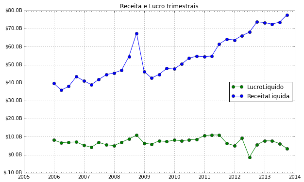

```python
import datetime
import matplotlib.dates as mdates
from matplotlib.ticker import FuncFormatter

years    = mdates.YearLocator()   # every year
months   = mdates.MonthLocator()  # every month
yearsFmt = mdates.DateFormatter('%Y')

fig, ax = plt.subplots(figsize=(10,6))

xx = [datetime.date(d.year, d.month, d.day) for d in oper_result.Data]
rects1 = ax.plot(xx, oper_result.LucroLiquido, 'go-')
rects2 = ax.plot(xx, oper_result.ReceitaLiquida, 'bo-')

ax.xaxis.set_major_locator(years)
ax.xaxis.set_major_formatter(yearsFmt)
ax.xaxis.set_minor_locator(months)

datemin = datetime.date(oper_result.Data.min().year, 1, 1)
datemax = datetime.date(oper_result.Data.max().year+1, 1, 1)
ax.set_xlim(datemin, datemax)

formatter = FuncFormatter(lambda x, pos: '$%1.1fB' % (x*1e-6))
ax.yaxis.set_major_formatter(formatter)

ax.set_title('Receita e Lucro trimestrais')
ax.legend( (rects1[0], rects2[0]), ('LucroLiquido', 'ReceitaLiquida'), loc='center right')
ax.grid(True)
```

O gráfico acima, que *by the way* me deu muito trabalho para criar exatamente da forma que eu queria (talvez no futuro eu escreva um *post* sobre isso), apresenta o resultado operacional da Petrobrás. Uma comparação da sua receita líquida, ao longo de aproximadamente 8 anos, contra o seu lucro líquido. É bastante claro que há uma diferença significativa entre o Lucro e a Receita. Esta última cresceu significativamente nos últimos anos, por outro lado o Lucro não acompanhou essa toada.

No entanto, eu gostaria de ver estes números consolidados por ano e avaliar esta evolução em um gráfico de barras. Para isso vamos criar uma coluna `Ano` no `DataFrame` e fazer o agrupamento por ela.

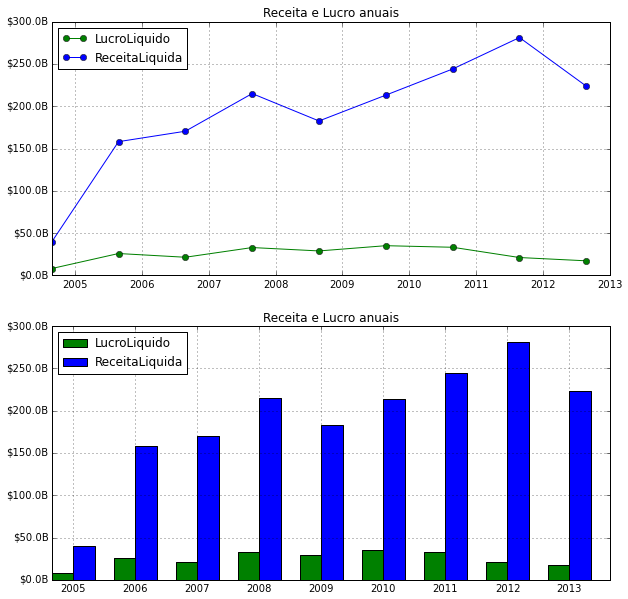

```python
oper_result['Ano'] = [d.year for d in oper_result.Data]
anual_result = oper_result.groupby(['Ano'])[['ReceitaLiquida', 'LucroLiquido']].sum()

fig, ax = plt.subplots(nrows=2, ncols=1, figsize=(10,10))

rects1 = ax[0].plot(anual_result.index, anual_result.LucroLiquido, 'go-')
rects2 = ax[0].plot(anual_result.index, anual_result.ReceitaLiquida, 'bo-')
ax[0].set_xticks(anual_result.index + 0.35)
ax[0].set_xticklabels( anual_result.index )
ax[0].grid(True)
ax[0].set_title('Receita e Lucro anuais')
ax[0].legend( (rects1[0], rects2[0]), ('LucroLiquido', 'ReceitaLiquida'), loc='upper left')
ax[0].yaxis.set_major_formatter(formatter)

rects1 = ax[1].bar(anual_result.index, anual_result.LucroLiquido, 0.35, color='g')
rects2 = ax[1].bar(anual_result.index+0.35, anual_result.ReceitaLiquida, 0.35, color='b')
ax[1].set_title('Receita e Lucro anuais')
ax[1].set_xticks(anual_result.index + 0.35)
ax[1].set_xticklabels( anual_result.index )
ax[1].legend( (rects1[0], rects2[0]), ('LucroLiquido', 'ReceitaLiquida'), loc='upper left')
ax[1].grid(True)
ax[1].yaxis.set_major_formatter(formatter)
```

Tarefa relativamente fácil com **pandas**, agrupar o `DataFrame` por uma coluna e definir qual função deve ser utilizada no agrupamento. No entanto, para mim seria mais intuitivo utilizar uma abordagem mais funcional para o agrupamento. Poderiamos ter algo como

```
oper_ressult.groupby(['Ano'], ['ReceitaLiquida', 'LucroLiquido'], sum)
```

Eventualmente poderiamos definir transformações diferentes para o agrupamento de diferentes colunas. De qualquer forma, o problema está resolvido e foi relativamente fácil.

O gráfico em barras acima é melhor do que o gráfico em linhas quando queremos tornar mais evidente que as quantidades, Lucro e Receita, são bastante diferentes, no que se refere a *massa*. É notório que o Lucro é muito menor do que a receita. O gráfico em barras traz a evolução temporal e enfatiza a ordem de grandeza das duas variáveis. O gráfico de linha dá mais foco a dinâmica e pode, eventualmente, negligenciar a ordem de grandeza, por outro lado torna mais evidente tendências nas variáveis.

Bem, essas variáveis não são difíceis de entender. Receita é o que a empresa fatura e lucro é o que ela põe no bolso. Não tá muito difícil ver que a distância entre o que a Petrobrás ganha e o que ela põe no bolso vem aumentando significativamente e não tem mágica, esse dinheiro tem que ir pra algum lugar. Então em termos de lucro a Petrobrás realmente deu uma estagnada nos últimos anos.

Mas apenas o lucro e a receita não definem essa questão. Outra variável importante e complementar ao que estamos observando é o [lucro pro ação](http://www.opequenoinvestidor.com.br/2010/11/compreendendo-os-indicadores-fundamentalistas/). Para calcular o lucro por ação basta dividir o lucro líquido pela quantidade total de ações da empresa. Essa informação pode ser obtida no site da [BM&F Bovespa](http://www.bmfbovespa.com.br/), em 2013 a Petrobrás tinhas 6.743.719.951 ações (somando Preferenciais e Ordinárias).

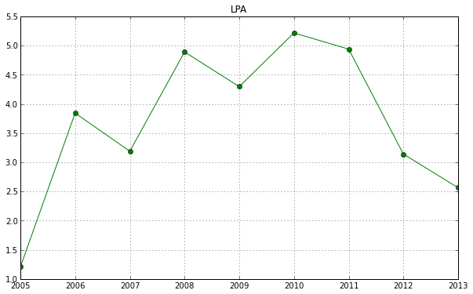

```python
anual_result.Qtd = 6743719951
anual_result.LPA = anual_result.LucroLiquido*1000/anual_result.Qtd
fig, ax = plt.subplots(figsize=(10,6))

ax.plot(anual_result.index, anual_result.LPA, 'go-')
ax.set_xticks(anual_result.index)
ax.set_xticklabels(anual_result.index)
ax.grid(True)
ax.set_title('LPA')
```

**LPA** significa lucro por ação e indica, em R$, quanto a empresa paga ao acionista por deter a sua ação. Como opequenoinvestidor menciona, o número por si não diz muita coisa, no entanto, se este número é crescente ao longo do tempo e a quantidade de ações da empresa permanece constante, significa que a empresa está lucrando e que sua ação está sofrendo os bons reflexos da sua performance e portanto o acionista está sendo recompensado.

No entanto, a Petrobrás aumentou o número de ações em 2010, ou seja, a empresa fez uma captação. Por isso o aumento da receita.

O gráfico acima não reflete os resultados apresentados no post do opequenoinvestidor e nem os números apresentados no site do [Bastter](http://www.bastter.com/mercado/acao/PETR.aspx). Acredito que isto aconteca porque não tenho a série da quantidade de ações por ano. No site da BM&F Bovespa tem apenas a quantidade de ações em 29/04/2013. Dado que houve a capitalização em 2010 a quantidade de ações antes de 2010 deve ser menor da que eu utilizei. Devemos então considerar esta série de LPA como uma *proxy*.

Entretanto é possível observar que o LPA vem decrescendo desde 2010, reflexo da captalização e da ausência de lucros expressivos, para compensar este aumento.

## Adicionando a série de preços da Petrobrás

Queria ainda de adicionar a esta análise o valor da ação da Petrobrás. Para capturar a série temporal da ação da Petrobrás vamos utilizar o [Quandl](http://www.quandl.com), que é um excelente serviço de datasets online.

```python
import Quandl
petr4 = Quandl.get("GOOG/BVMF_PETR4", authtoken='nJ1NhTYdEs2p3MsS4CVd')
petr4 = pd.DataFrame({'Fechamento' : list(petr4['Close']), 'Data' : list(petr4.index)}, index=np.arange(len(petr4)))
petr4.head()
```

```
Token nJ1NhTYdEs2p3MsS4CVd activated and saved for later use.
Returning Dataframe for  GOOG/BVMF_PETR4
```

|  | Data | Fechamento |
| --- | --- | --- |
| 0 | 2003-06-02 00:00:00 | 6.56 |
| 1 | 2003-06-03 00:00:00 | 6.55 |
| 2 | 2003-06-04 00:00:00 | 6.75 |
| 3 | 2003-06-05 00:00:00 | 6.74 |
| 4 | 2003-06-06 00:00:00 | 6.79 |

5 rows × 2 columns

Capturamos a série temporal das ações preferenciais da Petrobrás (PETR4) e para efeito de comparação vamos pegar o último ponto de cada ano para formar uma série temporal anual e comparar com os dados de receita e lucro.

```python
petr4['Ano'] = [d.year for d in petr4.Data]
g = petr4.groupby(['Ano'])
anual_petr4 = g.apply(lambda x: x.sort('Data').loc[:,['Ano', 'Fechamento']].tail(1))
anual_petr4.index = anual_petr4.Ano
anual_petr4 = anual_petr4.loc[:,'Fechamento']
anual_petr4.tail()
```

```
Ano
2010    27.29
2011    21.49
2012    19.52
2013    17.08
2014    15.10
Name: Fechamento, dtype: float64
```

Tendo a série anual, temos agora que fazer um `join` dos `DataFrame`.

```python
anual_result_2 = anual_result.join(anual_petr4, how='outer')
anual_result_2
```

| Ano | ReceitaLiquida | LucroLiquido | Fechamento |
| --- | --- | --- | --- |
| 2003 | NaN | NaN | 9.55 |
| 2004 | NaN | NaN | 12.14 |
| 2005 | 3.961811e+07 | 8141880.320 | 18.60 |
| 2006 | 1.582388e+08 | 25918920.704 | 24.90 |
| 2007 | 1.705777e+08 | 21511788.800 | 44.20 |
| 2008 | 2.151185e+08 | 32987791.358 | 22.84 |
| 2009 | 1.827101e+08 | 28981708.800 | 36.69 |
| 2010 | 2.132736e+08 | 35189366.276 | 27.29 |
| 2011 | 2.441761e+08 | 33313094.662 | 21.49 |
| 2012 | 2.813795e+08 | 21182441.472 | 19.52 |
| 2013 | 2.238619e+08 | 17288839.168 | 17.08 |
| 2014 | NaN | NaN | 15.10 |

12 rows × 3 columns

O `join` é legal porque ele atua sobre o `index` das estruturas de dado, e ai pode ser `DataFrame` ou `Series`, mas apenas `DataFrame` possui o método `join`. Portanto, Podemos apenas fazer o `join` entre `DataFrame` e de uma `Series` em um `DataFrame`, como vimos acima.

Utilizei o parâmetro `how=outer` para obter a maior abrangência dos índices e consequentemente as colunas `ReceitaLiquida` e `LucroLiquido` vieram com valores `NaN`, pois não possuem dados referentes aos anos de 2003, 2004 e 2014.

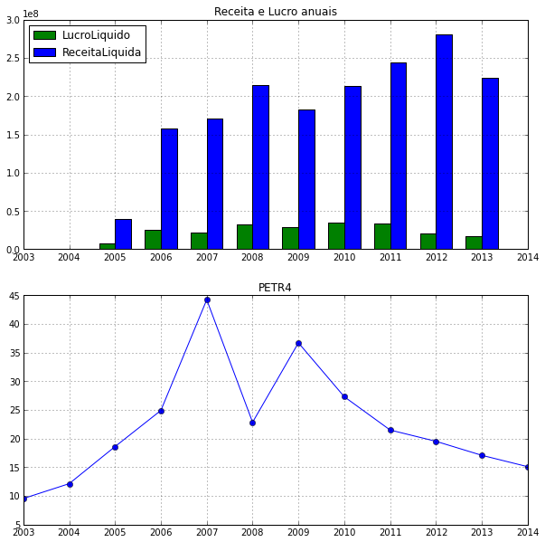

```python
fig, ax = plt.subplots(nrows=2, ncols=1, figsize=(10,10), dpi=300)

rects1 = ax[0].bar(anual_result_2.index, anual_result_2.LucroLiquido, 0.35, color='g')
rects2 = ax[0].bar(anual_result_2.index+0.35, anual_result_2.ReceitaLiquida, 0.35, color='b')
ax[0].set_title('Receita e Lucro anuais')
ax[0].set_xticks(anual_result_2.index + 0.35)
ax[0].set_xticklabels(anual_result_2.index)
ax[0].legend( (rects1[0], rects2[0]), ('LucroLiquido', 'ReceitaLiquida'), loc='upper left')
ax[0].grid(True)

ax[1].plot(anual_result_2.index, anual_result_2.Fechamento, 'o-')
ax[1].set_xticks(anual_result_2.index)
ax[1].set_xlim((2003,2014))
ax[1].set_title('PETR4')
ax[1].grid(True)
```

É importante notar que as colunas com `NaN` não aparecem no gráfico, ou seja, eu possuo um registro de índice mas não possuo ponto para o registro. No gráfico em barras não fica estranho, no entanto, no gráfico em linha ficariam segmentos soltos no meio do gráfico.

## Conclusão

Por ora, podemos observar com os dados:

- a discrepância entre receita e lucro
- a queda do lucro por ação

Ainda coloquei o gráfico de preços das ações junto dos resultados operacionais para avaliar como a variação nos preços estaria relacionada com estas variáveis. É possível observar que assim como o LPA o valor da ação vem diminuindo desde 2010, o que não é um bom indicador para os acionistas.

Vamos ficando por aqui mas a análise não terminou. Ainda temos outras variáveis para e o que foi colocado aqui é apenas o começinho do [*post*](http://www.opequenoinvestidor.com.br/2014/01/que-2014-seja-finalmente-um-novo-ano-para-petrobras/).

Na verdade o grosso do trabalho foi de importação, formatação e compreensão dos dados e como utilizar o **pandas** para tudo isso. Isso consome tempo mesmo. Nos próximos textos vamos direto ao ponto já trabalhando nas variáveis e esmiuçando os indicadores da empresa utilizando Python.

## Comments

© Wilson Freitas 2015-2018

Powered by Pelican